# Foreign Library Interface

## Creation of DynPort files

The creation of *DynPort* files from C header files is briefly described next. A tool chain, comprising of freely available components, is applied once on a build machine as depicted in Figure 4.

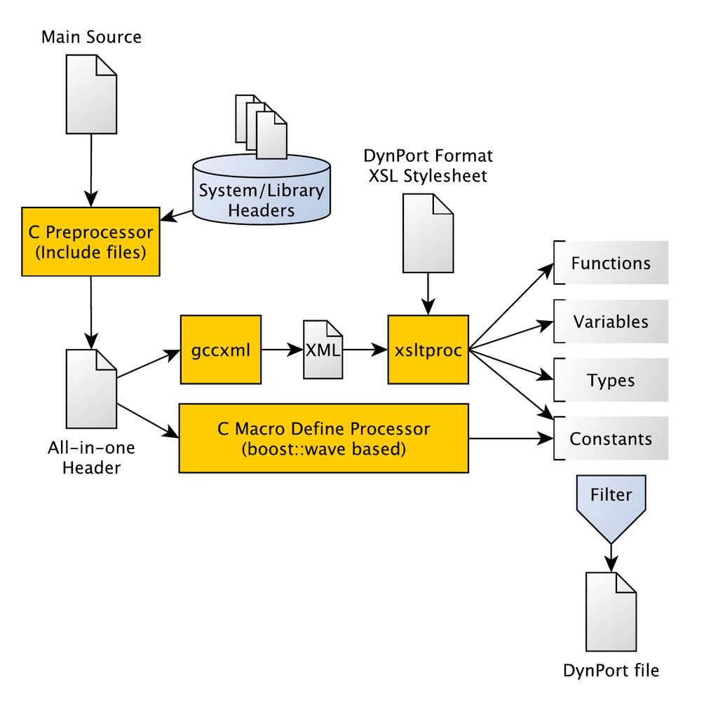

Figure 4: Tool-chain to create DynPort files from C headers

At first a main source file references the C header files of the library that should be made accessable via dynport. In a preprocessing phase the *GNU C Macro Processor* is used to process all `#include` statements using standard system search paths to create a concatenated *All-In-One* source file. *GCC-XML* (King 2004), a modified version of the GNU C compiler, transforms C header declarations to XML. The XML is further transformed to the final type signature format using [*xslproc*](https://CRAN.R-project.org/package=xslproc) (Veillard and B. Reese 2009), a XSLT (Clark 2001) processor, and a custom XSL stylesheet that has been implemented for the actual transformation from GCC-XML to the type signature text format.

C Macro `#define` statements are handled separately by a custom C Preprocessor implemented in C++ using the *boost wave* library (Kaiser 2011). An optional filter stage is used to include only elements with a certain pattern, such as a common prefix usually found in many libraries, e.g. ‘`SDL_`’. In a last step, the various fragments are assembled into a single text-file that represents the *DynPort* file.

# Limitations

During the creation of *DynPort* files, we encountered some cases (mainly for the SDL library) where we had to comment out some symbolic assignments (derived from C macro definitions) manually. These could not be converted as-is into valid R assignments because they consist of complex C expressions such as bit-shift operations. One could solve this problem by integrating a C interpreter within the tool-chain that deduces the appropriate type and value information from the replacement part of each C macro definitions; definitions with incomplete type could be rejected and constant values could be stored in a language-neutral encoding.

In order to use a single *DynPort* for a given C library across multiple platforms, its interface must be constant across platforms. *DynPort* does not support the conditional statements of the C preprocessor. Thus interfaces that use different types for arguments or structure fields depending on the architecture cannot be supported in a universal manner. For example, the *Objective-C Run-Time* C library of Mac OS X uses a different number of fields within certain `struct` data types depending on whether the architecture is *i386* or alternative *AMD64* in which case padding fields are inserted in the middle of the structure. We are aware of this problem although we have not encountered a conflict with the given palette of C libraries available via *DynPorts* to R. A possible work around for such cases would be to offer separate *DynPorts* for different architectures.

[*dyncall*](https://CRAN.R-project.org/package=dyncall) and [*dyncallback*](https://CRAN.R-project.org/package=dyncallback) currently lack support for handling `long double`, `struct` and `union` argument and return value types and architecture-specific vector types. Work is in progress to overcome this limitation. The middleware [*BridJ*](https://CRAN.R-project.org/package=BridJ) (Chafik 2011) for the Java VM and C/C++ libraries, which uses [*dyncall*](https://CRAN.R-project.org/package=dyncall), provides support for passing `struct` value types for a number of i386 and AMD64 platforms.

R character strings have a maximum size that can limit the number of library functions per `dynbind` function call. An improved *DynPort* file format and parser are being developed and are already available for [*luadyncall*](https://CRAN.R-project.org/package=luadyncall).

This version of *DynPort* does not capture the full range of the C type system. For example array and bit-field types are not supported; the pointer-to-function type in an argument list can only be specified using the void pointer `’*v’` or `’p’` instead of this (more informative) explicit type. An extended version of *DynPort*, that overcomes these inconveniences and that improves type safety, is being developed.

Certain restrictions apply when [*rdyncall*](https://CRAN.R-project.org/package=rdyncall) is used to work with C libraries. These arise from limitations in R. For example the handling of C `float` pointers/arrays and `char` pointer-to-pointer types are not implemented in R. The functions `.unpack` and `.pack` are powerful helper functions designed to overcome these and some other restrictions. Additional helper functions are included, such as `floatraw` and `floatraw2numeric` that translate numeric R vectors to C `float` arrays and vice versa.

The portable loading of shared libraries via `dynfind` might require fine-tuning the list of short names when using less common R platforms such as BSDs and Solaris.

# Related work

Several dynamic languages offer a flexible FFI, e.g. *ctypes* (Heller 2011) for Python, *alien* (Mascarenhas 2009) for Lua, [*Rffi*](https://CRAN.R-project.org/package=Rffi) (Temple Lang 2011) for R, *CFFI* (Bielman 2010) for Common LISP and the *FFI* module for Perl (Moore, G. Yahas, and A. Vorobey 2008) and Ruby (Meissner 2011). These all facilitate similar services such as foreign function calls and handling of foreign data. With the exception of *Rffi*, these also support wrapping of scripting functions as C callbacks. In most cases, the type information is specified in the grammar of the dynamic language. An exception to this is the *Perl FFI* that uses text-based type signatures similar to *rdyncall*.

*ctypeslib* (Kloss 2008) is an extension to *ctypes* that comes closest to the idea of *DynPorts* in which Python *ctypes* statements are automatically generated from C library header files, also using *GCC-XML*. In contrast, the *DynPort* framework contributes a *compact text-based* type information format that is also used as the main user-interface for various tasks in *rdyncall*. This software design is applicable across languages and thus type information can be *shared* across platforms and languages at the same time.

Specific alternatives to *dyncall* include *libffi* (Green 2011) and *ffcall* (Haible 2004). These are mature FFI libraries that use a *data-driven* C interface and have support for many platforms. Although not as popular as the first two, the *C/Invoke* library (Weisser 2007) also offers a similar service with bindings to Lua, Java and Kite. The *dyncall* library offers a *functional* C interface (inspired by the OpenGL API). It includes a comprehensive test suite and detailed documentation of calling conventions on a variety of platforms and compilers. As the framework was developed "de novo" we were free to introduce our own strategy to support open as well as commercial and embedded platforms. For example, the i386 Assembly (except for Plan9) is implemented in a common abstract syntax that translates to GNU and Microsoft Assembler. This makes sense here, because i386-based operating systems use a common C calling convention which we address using a *single* Assembly source. A by-product of this feature is that *dyncall* enables the user to call operating system foreign code on some architectures.

In contrast to the *dynamic* *zero-compilation* approach of *ctypeslib* and *rdyncall*, the majority of language bindings to libraries use a *compiled* approach in which code (handwritten or auto-generated) is compiled for each platform. *SWIG* (Beazley 2003) is a development tool for the automatic generation of language bindings. The user specifies the interface for a particular library in a C-like language and then chooses among the several supported languages (including R) to generate C sources that implement the binding for that particular library/language combination. *RGtk2* (Lawrence and D. Temple Lang 2011) offers R bindings for the *GTK+* GUI framework consisting of R and C code. These are produced by a custom code generator to offer carefully conceived mappings to the object-oriented *GObject* framework. The generated code includes features such as ownership management of returned objects using human annotations. While custom bindings offer the ability to take into account the features of a particular library and framework to offer very user-friendly mapping schemes, *rdyncall* aims to offer convenient access to C libraries in general but it requires users to know the details of the particular interface of a C library and the R run-time environment.

# Summary and Outlook

This paper introduces the *rdyncall* package[^5] that contributes an improved Foreign Function Interface for R. The FFI facilitates *direct* invocation of foreign functions *without* the need to compile wrappers in C. The FFI offers a dynamic cross-platform linkage framework to wrap and access *whole* C interfaces of native libraries from R. Instead of *compiling* bindings for every *library/language* combination, R bindings of a library are created dynamically at run-time in a data-driven manner via *DynPort* files, a cross-platform universal type information format. C libraries are made accessible in R as though they were extension packages and the R interface looks very similar to that of C. This enables system-level programming in R and brings a new wave of possibilities to R developers such as direct access to OpenGL across platforms as illustrated in the example. An initial repository of *DynPort*s for standard cross-platform portable C libraries comes with the package. Work is in progress for implementation of callback support on architectures already supported by the *dyncall* C library. The handling of foreign data types, which is currently implemented in R and C, is planned to be reimplemented as a C library and part of the *DynCall* project.

The *DynPort* facility in *rdyncall* consitutes an initial step in building up an infrastructure between scripting languages and C libraries. Analogous to the way in which R users enjoy quick access to the large pool of R software managed by CRAN, we envision an archive network in which C library developers can distribute their work across languages, users could then get quick access to the pool of C libraries from within scripting languages via automatic installation of precompiled components and using universal type information for cross-platform and cross-language dynamic bindings.

Adler and T. Philipp, D. 2011. *DynCall project*. November C library version 0.7. http://dyncall.org.

Beazley, D. M. 2003. *Automated scientific software scripting with SWIG*. Future Gener Comput Syst. 19: July ISSN 0167-739X doi10.1016/S0167-739X(02)00171-1. http://portal.acm.org/citation.cfm?id=860016.860018.

Bellard, F. 2005. *QEMU, a fast and portable dynamic translator*. In USENIX Annual Technical Conference FREENIX Track pages USENIX. http://www.usenix.org/events/usenix05/tech/freenix/bellard.html.

Bielman, J. 2010. *CFFI - common foreign function interface*. August CL library version 0.10.6. http://common-lisp.net/project/cffi/.

Chafik, O. 2011. *BridJ - Let Java & Scala call C, C++, Objective-C, C#..* Jun Java package version 0.5. http://code.google.com/p/bridj/.

Clark, J. 2001. *XSL transformations (XSLT) version 1.1*. W3C working draft W3C Aug. http://www.w3.org/TR/2001/WD-xslt11-20010824/.

———. 2007. *The Expat XML parser*. June C library version 2.0.1. http://expat.sourceforge.net/.

Flanagan and Y. Matsumoto, D. 2008. *The Ruby Programming Language*. O’Reilly Cambridge.

Gavare, A. 2010. *GXEmul: a framework for full-system computer architecture emulation*. February Program version 0.6.0. http://gxemul.sourceforge.net/.

Green, A. 2011. *libffi - a portable foreign function interface library*. August C library version 3.0.10. http://sourceware.org/libffi/.

Haible, B. 2004. *ffcall - foreign function call libraries*. June C library version 1.10. http://www.gnu.org/s/libffcall/.

Heller, T. 2011. *ctypes - A foreign function library for Python*. October. http://starship.python.net/crew/theller/ctypes/.

Ierusalimschy, L. H. de Figueiredo, and W. C. Filho, R. 1996. *Lua – an extensible extension language*. Software – Practice; Experience 26 (6): June.

Kaiser, H. 2011. *Wave V2.0 - Boost C++ Libraries*. Boost C++ Library Version 1.45 Wave C++ Library Version 2.1.0. http://www.boost.org/doc/libs/release/libs/wave/index.htmlJuly.

Kim, E. E. 2001. *A triumph of simplicity: James Clark on markup languages and XML*. Dr Dobb’s Journal of Software Tools 26(7): 56 July ISSN 1044-789X. http://www.ddj.com/.

King, B. 2004. *GCC-XML*. February Program version 0.6.0. http://www.gccxml.org.

Kloss, G. K. 2008. *Automatic C library wrapping – ctypes from the trenches*. The Python Papers 3 (3) ISSN 1834-3147.

Lantinga, S. 2009. *libSDL: Simple DirectMedia layer*. October C library version 1.2.14. http://www.libsdl.org/.

Lawrence and D. Temple Lang, M. 2011. *RGtk2: A graphical user interface toolkit for R*. Journal of Statistical Software ISSN 15487660. http://www.jstatsoft.org/v37/i08/paper.

Mascarenhas, F. 2009. *Alien - pure Lua extensions*. October Lua module version 0.5.1. http://alien.luaforge.net/.

Meissner, W. 2011. *Ruby-FFI*. October Ruby package version 1.0.10. https://github.com/ffi/ffi/wiki.

Moore, G. Yahas, and A. Vorobey, P. 2008. *FFI - Perl foreign function interface*. gaal/FFI/FFI.pm September Perl module version 1.04. http://search.cpan.org/.

OpenGL Architecture Review Board, D. Shreiner, M. Woo, J. Neider, and T. Davis. 2005. *OpenGL(R) Programming Guide: The Official Guide to Learning OpenGL(R), Version 2*. Addison Wesley.

Pendleton, B. 2003. *Game programming with the Simple DirectMedia Layer (SDL)*. Linux Journal 110: 42 44 46 48 June ISSN 1075-3583.

Philipp, T. 2011. *DynOS Project*. May. http://dyncall.org/dynos.

R Development Core Team. 2010. *Writing R Extesions*. R Foundation for Statistical Computing Vienna Austria. http://www.R-project.org.

Rossum and F. L. Drake, Jr., G. van. 2005. *Python Language Reference Manual*. Network Theory Ltd. http://www.network-theory.co.uk/python/language/.

Temple Lang, D. 2011. *Rffi for run-time invocation of arbitrary compiled routines from R*. January R package version 0.3-0. http://www.omegahat.org/Rffi/.

Tierney, L. 2003. *A simple implementation of name spaces for R*. luke/R/namespaces/morenames.pdf,May. http://www.stat.uiowa.edu/.

Veillard and B. Reese, D. 2009. *The XSLT C library for GNOME*. September C library version 1.1.26. http://xmlsoft.org/XSLT/.

Weisser, W. 2007. *C/Invoke - version 1.0 - easily call C from any language*. January C library version 1.0. http://cinvoke.teegra.net/index.html.

[^1]: We omit here the details such as registering C functions which is described in detail in the R Manual ‘*Writing R Extensions*’ (R Development Core Team 2010).
[^2]: The maximum number of arguments is limited by the amount of memory required for prebuffering a single call. It is currently fixed to 4 kilobyte (approx. 512-1024 arguments).
[^3]: Possible C math library names are `libm.so` and `MSVCRT.DLL` in locations such as `/lib`, `/usr/lib`, `/lib64`, `/usr/lib64`, `C:\WINDOWS\SYSTEM32` etc..
[^4]: Passing of `long double`, `struct` and `union` argument/return C value types are currently work in progress.
[^5]: Version 0.7.4 on CRAN as of this writing.